# Predict Bike Sharing Demand with AutoGluon Template

### Download and explore dataset

### Go to the bike sharing demand competition and agree to the terms

```python
# Download the dataset, it will be in a .zip file so you'll need to unzip it as well.
!kaggle competitions download -c bike-sharing-demand
```

```
bike-sharing-demand.zip: Skipping, found more recently modified local copy (use --force to force download)
```

```python
# If you already downloaded it you can use the -o command to overwrite the file
!unzip -o bike-sharing-demand.zip
```

```
Archive:  bike-sharing-demand.zip
  inflating: sampleSubmission.csv
  inflating: test.csv
  inflating: train.csv
```

```python
from autogluon.tabular import TabularPredictor
```

```python
import pandas as pd
```

```python
# Create the train dataset in pandas by reading the csv
# Set the parsing of the datetime column so you can use some of the `dt` features in pandas later
train = pd.read_csv("train.csv", parse_dates=["datetime"])
train.head()
```

|  | datetime | season | holiday | workingday | weather | temp | atemp | humidity | windspeed | casual | registered | count |
| --- | --- | --- | --- | --- | --- | --- | --- | --- | --- | --- | --- | --- |
| 0 | 2011-01-01 00:00:00 | 1 | 0 | 0 | 1 | 9.84 | 14.395 | 81 | 0.0 | 3 | 13 | 16 |
| 1 | 2011-01-01 01:00:00 | 1 | 0 | 0 | 1 | 9.02 | 13.635 | 80 | 0.0 | 8 | 32 | 40 |
| 2 | 2011-01-01 02:00:00 | 1 | 0 | 0 | 1 | 9.02 | 13.635 | 80 | 0.0 | 5 | 27 | 32 |
| 3 | 2011-01-01 03:00:00 | 1 | 0 | 0 | 1 | 9.84 | 14.395 | 75 | 0.0 | 3 | 10 | 13 |
| 4 | 2011-01-01 04:00:00 | 1 | 0 | 0 | 1 | 9.84 | 14.395 | 75 | 0.0 | 0 | 1 | 1 |

```python
# Simple output of the train dataset to view some of the min/max/varition of the dataset features.
train.describe()
```

|  | season | holiday | workingday | weather | temp | atemp | humidity | windspeed | casual | registered | count |
| --- | --- | --- | --- | --- | --- | --- | --- | --- | --- | --- | --- |
| count | 10886.000000 | 10886.000000 | 10886.000000 | 10886.000000 | 10886.00000 | 10886.000000 | 10886.000000 | 10886.000000 | 10886.000000 | 10886.000000 | 10886.000000 |
| mean | 2.506614 | 0.028569 | 0.680875 | 1.418427 | 20.23086 | 23.655084 | 61.886460 | 12.799395 | 36.021955 | 155.552177 | 191.574132 |
| std | 1.116174 | 0.166599 | 0.466159 | 0.633839 | 7.79159 | 8.474601 | 19.245033 | 8.164537 | 49.960477 | 151.039033 | 181.144454 |
| min | 1.000000 | 0.000000 | 0.000000 | 1.000000 | 0.82000 | 0.760000 | 0.000000 | 0.000000 | 0.000000 | 0.000000 | 1.000000 |
| 25% | 2.000000 | 0.000000 | 0.000000 | 1.000000 | 13.94000 | 16.665000 | 47.000000 | 7.001500 | 4.000000 | 36.000000 | 42.000000 |
| 50% | 3.000000 | 0.000000 | 1.000000 | 1.000000 | 20.50000 | 24.240000 | 62.000000 | 12.998000 | 17.000000 | 118.000000 | 145.000000 |
| 75% | 4.000000 | 0.000000 | 1.000000 | 2.000000 | 26.24000 | 31.060000 | 77.000000 | 16.997900 | 49.000000 | 222.000000 | 284.000000 |
| max | 4.000000 | 1.000000 | 1.000000 | 4.000000 | 41.00000 | 45.455000 | 100.000000 | 56.996900 | 367.000000 | 886.000000 | 977.000000 |

```python
#General info
train.info()
```

```
<class 'pandas.core.frame.DataFrame'>
RangeIndex: 10886 entries, 0 to 10885
Data columns (total 12 columns):
 #   Column      Non-Null Count  Dtype
---  ------      --------------  -----
 0   datetime    10886 non-null  datetime64[ns]
 1   season      10886 non-null  int64
 2   holiday     10886 non-null  int64
 3   workingday  10886 non-null  int64
 4   weather     10886 non-null  int64
 5   temp        10886 non-null  float64
 6   atemp       10886 non-null  float64
 7   humidity    10886 non-null  int64
 8   windspeed   10886 non-null  float64
 9   casual      10886 non-null  int64
 10  registered  10886 non-null  int64
 11  count       10886 non-null  int64
dtypes: datetime64[ns](1), float64(3), int64(8)
memory usage: 1020.7 KB
```

```python
# Create the test pandas dataframe in pandas by reading the csv, remember to parse the datetime!
test = pd.read_csv("test.csv", parse_dates=["datetime"])
test.head()
```

|  | datetime | season | holiday | workingday | weather | temp | atemp | humidity | windspeed |
| --- | --- | --- | --- | --- | --- | --- | --- | --- | --- |
| 0 | 2011-01-20 00:00:00 | 1 | 0 | 1 | 1 | 10.66 | 11.365 | 56 | 26.0027 |
| 1 | 2011-01-20 01:00:00 | 1 | 0 | 1 | 1 | 10.66 | 13.635 | 56 | 0.0000 |
| 2 | 2011-01-20 02:00:00 | 1 | 0 | 1 | 1 | 10.66 | 13.635 | 56 | 0.0000 |
| 3 | 2011-01-20 03:00:00 | 1 | 0 | 1 | 1 | 10.66 | 12.880 | 56 | 11.0014 |
| 4 | 2011-01-20 04:00:00 | 1 | 0 | 1 | 1 | 10.66 | 12.880 | 56 | 11.0014 |

```python
# Same thing as train and test dataset
submission = pd.read_csv("sampleSubmission.csv")
submission.head()
```

|  | datetime | count |
| --- | --- | --- |
| 0 | 2011-01-20 00:00:00 | 0 |
| 1 | 2011-01-20 01:00:00 | 0 |
| 2 | 2011-01-20 02:00:00 | 0 |
| 3 | 2011-01-20 03:00:00 | 0 |
| 4 | 2011-01-20 04:00:00 | 0 |

```python
features = ["season", "holiday", "weather", "temp", "atemp", "humidity", "windspeed", "count"]
```

## Step 3: Train a model using AutoGluon’s Tabular Prediction

Requirements:

- We are prediting `count`, so it is the label we are setting.
- Ignore `casual` and `registered` columns as they are also not present in the test dataset.
- Use the `root_mean_squared_error` as the metric to use for evaluation.
- Set a time limit of 10 minutes (600 seconds).
- Use the preset `best_quality` to focus on creating the best model.

```python
features = ["season", "holiday", "weather", "temp", "atemp", "humidity", "windspeed", "count"]
predictor = TabularPredictor(label="count",
                             eval_metric="root_mean_squared_error").fit(train_data=train[features],
                                                                        time_limit=600, presets="best_quality")
```

```
No path specified. Models will be saved in: "AutogluonModels/ag-20230202_111351/"
Presets specified: ['best_quality']
Stack configuration (auto_stack=True): num_stack_levels=1, num_bag_folds=8, num_bag_sets=20
Beginning AutoGluon training ... Time limit = 600s
AutoGluon will save models to "AutogluonModels/ag-20230202_111351/"
AutoGluon Version:  0.6.2
Python Version:     3.7.10
Operating System:   Linux
Platform Machine:   x86_64
Platform Version:   #1 SMP Fri Dec 9 09:57:03 UTC 2022
Train Data Rows:    10886
Train Data Columns: 7
Label Column: count
Preprocessing data ...
AutoGluon infers your prediction problem is: 'regression' (because dtype of label-column == int and many unique label-values observed).
	Label info (max, min, mean, stddev): (977, 1, 191.57413, 181.14445)
	If 'regression' is not the correct problem_type, please manually specify the problem_type parameter during predictor init (You may specify problem_type as one of: ['binary', 'multiclass', 'regression'])
Using Feature Generators to preprocess the data ...
Fitting AutoMLPipelineFeatureGenerator...
	Available Memory:                    3005.8 MB
	Train Data (Original)  Memory Usage: 0.61 MB (0.0% of available memory)
	Inferring data type of each feature based on column values. Set feature_metadata_in to manually specify special dtypes of the features.
	Stage 1 Generators:
		Fitting AsTypeFeatureGenerator...
			Note: Converting 1 features to boolean dtype as they only contain 2 unique values.
	Stage 2 Generators:
		Fitting FillNaFeatureGenerator...
	Stage 3 Generators:
		Fitting IdentityFeatureGenerator...
	Stage 4 Generators:
		Fitting DropUniqueFeatureGenerator...
	Types of features in original data (raw dtype, special dtypes):
		('float', []) : 3 | ['temp', 'atemp', 'windspeed']
		('int', [])   : 4 | ['season', 'holiday', 'weather', 'humidity']
	Types of features in processed data (raw dtype, special dtypes):
		('float', [])     : 3 | ['temp', 'atemp', 'windspeed']
		('int', [])       : 3 | ['season', 'weather', 'humidity']
		('int', ['bool']) : 1 | ['holiday']
	0.1s = Fit runtime
	7 features in original data used to generate 7 features in processed data.
```

[output cut: 97 more lines]

```
	Fitting 8 child models (S1F1 - S1F8) | Fitting with ParallelLocalFoldFittingStrategy
	Time limit exceeded... Skipping NeuralNetTorch_BAG_L2.
Fitting model: LightGBMLarge_BAG_L2 ... Training model for up to 12.9s of the 12.87s of remaining time.
2023-02-02 11:23:38,372	ERROR worker.py:400 -- Unhandled error (suppress with 'RAY_IGNORE_UNHANDLED_ERRORS=1'): The worker died unexpectedly while executing this task. Check python-core-worker-*.log files for more information.
	Fitting 8 child models (S1F1 - S1F8) | Fitting with ParallelLocalFoldFittingStrategy
	-144.784	 = Validation score   (-root_mean_squared_error)
	28.17s	 = Training   runtime
	0.14s	 = Validation runtime
Completed 1/20 k-fold bagging repeats ...
Fitting model: WeightedEnsemble_L3 ... Training model for up to 360.0s of the -19.2s of remaining time.
	-142.4041	 = Validation score   (-root_mean_squared_error)
	0.66s	 = Training   runtime
	0.0s	 = Validation runtime
AutoGluon training complete, total runtime = 620.05s ... Best model: "WeightedEnsemble_L3"
TabularPredictor saved. To load, use: predictor = TabularPredictor.load("AutogluonModels/ag-20230202_111351/")
```

### Review AutoGluon's training run with ranking of models that did the best.

```python
predictor.fit_summary()
```

```
*** Summary of fit() ***
Estimated performance of each model:
                     model   score_val  pred_time_val    fit_time  pred_time_val_marginal  fit_time_marginal  stack_level  can_infer  fit_order
0      WeightedEnsemble_L3 -142.404111       5.460218  398.482571                0.000890           0.656214            3       True         20
1     ExtraTreesMSE_BAG_L2 -142.982624       4.784332  258.858981                0.761845           7.574884            2       True         16
2          CatBoost_BAG_L2 -144.083015       4.065328  289.655539                0.042841          38.371442            2       True         15
3        LightGBMXT_BAG_L2 -144.136003       4.279526  274.478236                0.257039          23.194139            2       True         12
4           XGBoost_BAG_L2 -144.309521       4.215995  284.156142                0.193508          32.872045            2       True         18
5          LightGBM_BAG_L2 -144.561838       4.104140  272.617613                0.081653          21.333516            2       True         13
6      WeightedEnsemble_L2 -144.628020       1.494278  219.446269                0.001020           0.813555            2       True         11
7   NeuralNetFastAI_BAG_L2 -144.731752       4.503975  357.379429                0.481488         106.095332            2       True         17
8     LightGBMLarge_BAG_L2 -144.783988       4.161378  279.450324                0.138891          28.166227            2       True         19
9   RandomForestMSE_BAG_L2 -144.899741       4.654530  281.706181                0.632043          30.422084            2       True         14
10         CatBoost_BAG_L1 -146.611050       0.039315   32.639424                0.039315          32.639424            1       True          6
11    LightGBMLarge_BAG_L1 -146.781478       0.151181   22.897270                0.151181          22.897270            1       True         10
12         LightGBM_BAG_L1 -146.851695       0.183273   19.180070                0.183273          19.180070            1       True          4
13          XGBoost_BAG_L1 -147.007226       0.215600   27.585585                0.215600          27.585585            1       True          9
14  NeuralNetFastAI_BAG_L1 -147.285490       0.393384  113.098023                0.393384         113.098023            1       True          8
15       LightGBMXT_BAG_L1 -148.410619       1.777285   26.926837                1.777285          26.926837            1       True          3
16    ExtraTreesMSE_BAG_L1 -154.571883       0.510504    3.232342                0.510504           3.232342            1       True          7
17  RandomForestMSE_BAG_L1 -155.978722       0.531129    5.640292                0.531129           5.640292            1       True          5
18   KNeighborsUnif_BAG_L1 -160.517467       0.104442    0.028824                0.104442           0.028824            1       True          1
19   KNeighborsDist_BAG_L1 -169.654635       0.116373    0.055430                0.116373           0.055430            1       True          2
Number of models trained: 20
Types of models trained:
{'StackerEnsembleModel_RF', 'StackerEnsembleModel_XGBoost', 'StackerEnsembleModel_LGB', 'StackerEnsembleModel_NNFastAiTabular', 'StackerEnsembleModel_XT', 'WeightedEnsembleModel', 'StackerEnsembleModel_CatBoost', 'StackerEnsembleModel_KNN'}
Bagging used: True  (with 8 folds)
Multi-layer stack-ensembling used: True  (with 3 levels)
Feature Metadata (Processed):
(raw dtype, special dtypes):
('float', [])     : 3 | ['temp', 'atemp', 'windspeed']
('int', [])       : 3 | ['season', 'weather', 'humidity']
('int', ['bool']) : 1 | ['holiday']
Plot summary of models saved to file: AutogluonModels/ag-20230202_111351/SummaryOfModels.html
*** End of fit() summary ***
```

[output not shown]

[output cut: 199 more lines]

[output not shown]

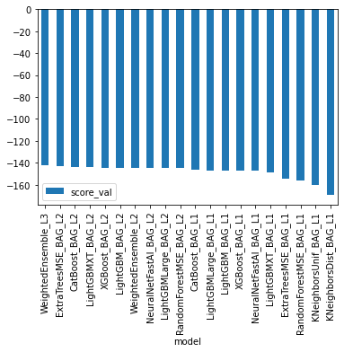

```python
predictor.leaderboard(silent=True).plot(kind="bar", x="model", y="score_val")
```

### Create predictions from test dataset

```python
predictions = predictor.predict(test)
predictions.head()
```

```
0    100.224907
1     59.785328
2     59.785328
3     57.613285
4     57.613285
Name: count, dtype: float32
```

#### NOTE: Kaggle will reject the submission if we don't set everything to be > 0.

```python
# Describe the `predictions` series to see if there are any negative values
predictions.describe()
```

```
count    6493.000000
mean      191.282867
std       109.258423
min        17.654490
25%       103.511810
50%       166.106232
75%       268.497772
max       584.683472
Name: count, dtype: float64
```

```python
# How many negative values do we have?
(predictions < 0).any().any()
```

```
False
```

### Set predictions to submission dataframe, save, and submit

```python
submission["count"] = predictions
submission.to_csv("submission_initial.csv", index=False)
```

```python
!kaggle competitions submit -c bike-sharing-demand -f submission_initial.csv -m "first raw submission"
```

```
Successfully submitted to Bike Sharing Demand
```

#### View submission via the command line or in the web browser under the competition's page - `My Submissions`

```python
!kaggle competitions submissions -c bike-sharing-demand | tail -n +1 | head -n 6
```

```
fileName                     date                 description           status    publicScore  privateScore
---------------------------  -------------------  --------------------  --------  -----------  ------------
submission_initial.csv       2023-02-02 11:26:30  first raw submission  complete  1.32970      1.32970
submission_new_features.csv  2023-02-02 10:37:03  new features          error
submission.csv               2023-02-02 10:12:06  first raw submission  complete  1.33244      1.33244
submission.csv               2023-02-02 09:47:33  first raw submission  complete  1.78354      1.78354
```

## Step 4: Exploratory Data Analysis and Creating an additional feature

- Any additional feature will do, but a great suggestion would be to separate out the datetime into hour, day, or month parts.

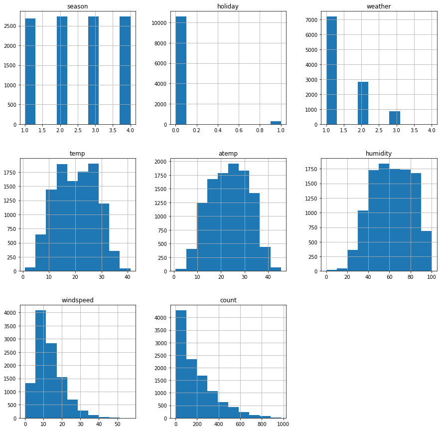

```python
# Create a histogram of all features to show the distribution of each one relative to the data. This is part of the exploritory data analysis
train[features].hist(figsize=(15,15));
```

```python
# create a new feature
train["hour"] = train["datetime"].dt.hour
test["hour"] = test["datetime"].dt.hour
```

## Make category types for these so models know they are not just numbers

- AutoGluon originally sees these as ints, but in reality they are int representations of a category.
- Setting the dtype to category will classify these as categories in AutoGluon.

```python
train["season"] = train["season"].astype("category")
train["weather"] = train["weather"].astype("category")
test["season"] = test["season"].astype("category")
test["weather"] = test["weather"].astype("category")
```

```python
# View are new feature
train.head()
```

|  | datetime | season | holiday | workingday | weather | temp | atemp | humidity | windspeed | casual | registered | count | hour |
| --- | --- | --- | --- | --- | --- | --- | --- | --- | --- | --- | --- | --- | --- |
| 0 | 2011-01-01 00:00:00 | 1 | 0 | 0 | 1 | 9.84 | 14.395 | 81 | 0.0 | 3 | 13 | 16 | 0 |
| 1 | 2011-01-01 01:00:00 | 1 | 0 | 0 | 1 | 9.02 | 13.635 | 80 | 0.0 | 8 | 32 | 40 | 1 |
| 2 | 2011-01-01 02:00:00 | 1 | 0 | 0 | 1 | 9.02 | 13.635 | 80 | 0.0 | 5 | 27 | 32 | 2 |
| 3 | 2011-01-01 03:00:00 | 1 | 0 | 0 | 1 | 9.84 | 14.395 | 75 | 0.0 | 3 | 10 | 13 | 3 |
| 4 | 2011-01-01 04:00:00 | 1 | 0 | 0 | 1 | 9.84 | 14.395 | 75 | 0.0 | 0 | 1 | 1 | 4 |

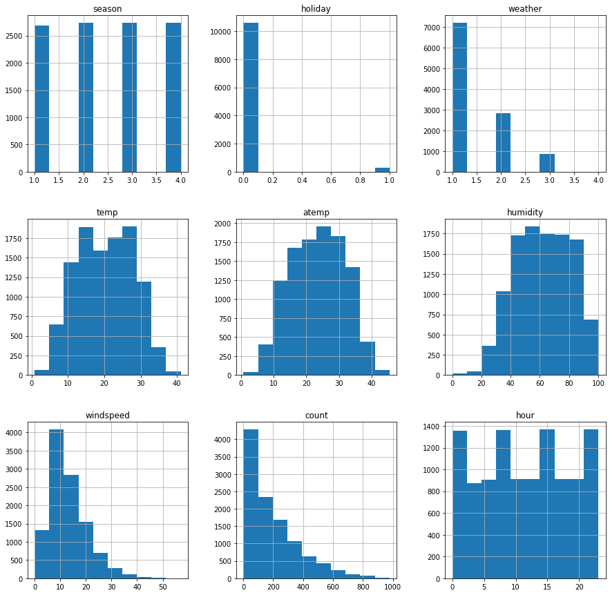

```python
# View histogram of all features again now with the hour feature
features_new = ["season", "holiday", "weather", "temp", "atemp", "humidity", "windspeed", "count", "hour"]
train[features_new].hist(figsize=(15,15));
```

## Step 5: Rerun the model with the same settings as before, just with more features

```python
predictor_new_features = TabularPredictor(label="count",
                             eval_metric="root_mean_squared_error").fit(train_data=train[features_new],
                                                                        time_limit=600, presets="best_quality")
```

```
No path specified. Models will be saved in: "AutogluonModels/ag-20230202_113036/"
Presets specified: ['best_quality']
Stack configuration (auto_stack=True): num_stack_levels=1, num_bag_folds=8, num_bag_sets=20
Beginning AutoGluon training ... Time limit = 600s
AutoGluon will save models to "AutogluonModels/ag-20230202_113036/"
AutoGluon Version:  0.6.2
Python Version:     3.7.10
Operating System:   Linux
Platform Machine:   x86_64
Platform Version:   #1 SMP Fri Dec 9 09:57:03 UTC 2022
Train Data Rows:    10886
Train Data Columns: 8
Label Column: count
Preprocessing data ...
AutoGluon infers your prediction problem is: 'regression' (because dtype of label-column == int and many unique label-values observed).
	Label info (max, min, mean, stddev): (977, 1, 191.57413, 181.14445)
	If 'regression' is not the correct problem_type, please manually specify the problem_type parameter during predictor init (You may specify problem_type as one of: ['binary', 'multiclass', 'regression'])
Using Feature Generators to preprocess the data ...
Fitting AutoMLPipelineFeatureGenerator...
	Available Memory:                    2105.24 MB
	Train Data (Original)  Memory Usage: 0.54 MB (0.0% of available memory)
	Inferring data type of each feature based on column values. Set feature_metadata_in to manually specify special dtypes of the features.
	Stage 1 Generators:
		Fitting AsTypeFeatureGenerator...
			Note: Converting 1 features to boolean dtype as they only contain 2 unique values.
	Stage 2 Generators:
		Fitting FillNaFeatureGenerator...
	Stage 3 Generators:
		Fitting IdentityFeatureGenerator...
		Fitting CategoryFeatureGenerator...
			Fitting CategoryMemoryMinimizeFeatureGenerator...
	Stage 4 Generators:
		Fitting DropUniqueFeatureGenerator...
	Types of features in original data (raw dtype, special dtypes):
		('category', []) : 2 | ['season', 'weather']
		('float', [])    : 3 | ['temp', 'atemp', 'windspeed']
		('int', [])      : 3 | ['holiday', 'humidity', 'hour']
	Types of features in processed data (raw dtype, special dtypes):
		('category', [])  : 2 | ['season', 'weather']
		('float', [])     : 3 | ['temp', 'atemp', 'windspeed']
```

[output cut: 87 more lines]

```
	-95.1719	 = Validation score   (-root_mean_squared_error)
	7.46s	 = Training   runtime
	0.62s	 = Validation runtime
Fitting model: NeuralNetFastAI_BAG_L2 ... Training model for up to 11.51s of the 11.48s of remaining time.
	Fitting 8 child models (S1F1 - S1F8) | Fitting with ParallelLocalFoldFittingStrategy
	-101.535	 = Validation score   (-root_mean_squared_error)
	32.51s	 = Training   runtime
	0.52s	 = Validation runtime
Completed 1/20 k-fold bagging repeats ...
Fitting model: WeightedEnsemble_L3 ... Training model for up to 360.0s of the -24.96s of remaining time.
	-94.6403	 = Validation score   (-root_mean_squared_error)
	0.41s	 = Training   runtime
	0.0s	 = Validation runtime
AutoGluon training complete, total runtime = 625.62s ... Best model: "WeightedEnsemble_L3"
TabularPredictor saved. To load, use: predictor = TabularPredictor.load("AutogluonModels/ag-20230202_113036/")
```

```python
predictor_new_features.fit_summary()
```

```
*** Summary of fit() ***
Estimated performance of each model:
                     model   score_val  pred_time_val    fit_time  pred_time_val_marginal  fit_time_marginal  stack_level  can_infer  fit_order
0      WeightedEnsemble_L3  -94.640347      10.547273  518.892590                0.001143           0.413148            3       True         18
1      WeightedEnsemble_L2  -95.097499       5.254352  307.875040                0.001420           0.836720            2       True         11
2          CatBoost_BAG_L2  -95.136825       7.831205  448.815521                0.132082          63.839701            2       True         15
3     ExtraTreesMSE_BAG_L2  -95.171888       8.322790  392.431984                0.623667           7.456164            2       True         16
4        LightGBMXT_BAG_L2  -95.711990       7.890023  407.550085                0.190900          22.574265            2       True         12
5   RandomForestMSE_BAG_L2  -95.814240       9.270389  414.676590                1.571267          29.700770            2       True         14
6        LightGBMXT_BAG_L1  -95.850003       3.894700   41.305061                3.894700          41.305061            1       True          3
7          CatBoost_BAG_L1  -96.306910       0.130941  141.948436                0.130941         141.948436            1       True          6
8          LightGBM_BAG_L2  -96.353285       7.807061  406.902406                0.107938          21.926586            2       True         13
9          LightGBM_BAG_L1  -97.143407       0.375645   21.129395                0.375645          21.129395            1       True          4
10          XGBoost_BAG_L1  -97.208632       0.974854   30.949755                0.974854          30.949755            1       True          9
11    LightGBMLarge_BAG_L1  -98.239588       0.335212   21.995342                0.335212          21.995342            1       True         10
12  RandomForestMSE_BAG_L1 -100.882380       0.572552    7.347213                0.572552           7.347213            1       True          5
13    ExtraTreesMSE_BAG_L1 -100.990542       0.553588    3.839226                0.553588           3.839226            1       True          7
14  NeuralNetFastAI_BAG_L2 -101.535020       8.219114  417.482806                0.519991          32.506986            2       True         17
15  NeuralNetFastAI_BAG_L1 -101.885249       0.450316  116.379210                0.450316         116.379210            1       True          8
16   KNeighborsUnif_BAG_L1 -124.768254       0.206891    0.023782                0.206891           0.023782            1       True          1
17   KNeighborsDist_BAG_L1 -125.617695       0.204423    0.058399                0.204423           0.058399            1       True          2
Number of models trained: 18
Types of models trained:
{'StackerEnsembleModel_RF', 'StackerEnsembleModel_XGBoost', 'StackerEnsembleModel_LGB', 'StackerEnsembleModel_NNFastAiTabular', 'StackerEnsembleModel_XT', 'WeightedEnsembleModel', 'StackerEnsembleModel_CatBoost', 'StackerEnsembleModel_KNN'}
Bagging used: True  (with 8 folds)
Multi-layer stack-ensembling used: True  (with 3 levels)
Feature Metadata (Processed):
(raw dtype, special dtypes):
('category', [])  : 2 | ['season', 'weather']
('float', [])     : 3 | ['temp', 'atemp', 'windspeed']
('int', [])       : 2 | ['humidity', 'hour']
('int', ['bool']) : 1 | ['holiday']
Plot summary of models saved to file: AutogluonModels/ag-20230202_113036/SummaryOfModels.html
*** End of fit() summary ***
```

[output not shown]

[output cut: 175 more lines]

[output not shown]

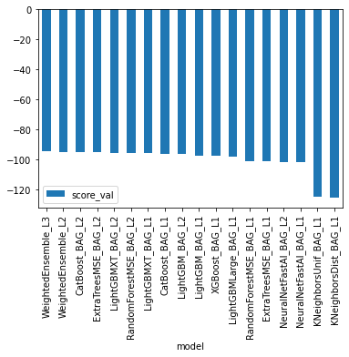

```python
predictor_new_features.leaderboard(silent=True).plot(kind="bar", x="model", y="score_val")
```

```python
# Remember to set all negative values to zero
predictions_new_features = predictor_new_features.predict(test)
predictions_new_features.head()
```

```
0    20.850567
1    15.574865
2    11.777503
3     7.327208
4     4.490149
Name: count, dtype: float32
```

```python
#Checking if there are any negative values
predictions_new_features.describe()
```

```
count    6493.000000
mean      187.982681
std       153.299332
min         1.517045
25%        52.441181
50%       159.112534
75%       280.184479
max       733.534546
Name: count, dtype: float64
```

```python
# Same submitting predictions
submission_new_features = submission
submission_new_features["count"] = predictions_new_features
submission_new_features.to_csv("submission_new_features.csv", index=False)
```

```python
!kaggle competitions submit -c bike-sharing-demand -f submission_new_features.csv -m "new features"
```

```
Successfully submitted to Bike Sharing Demand
```

```python
!kaggle competitions submissions -c bike-sharing-demand | tail -n +1 | head -n 6
```

```
fileName                     date                 description           status    publicScore  privateScore
---------------------------  -------------------  --------------------  --------  -----------  ------------
submission_new_features.csv  2023-02-02 11:42:46  new features          complete  0.67867      0.67867
submission_initial.csv       2023-02-02 11:26:30  first raw submission  complete  1.32970      1.32970
submission_new_features.csv  2023-02-02 10:37:03  new features          error
submission.csv               2023-02-02 10:12:06  first raw submission  complete  1.33244      1.33244
```

## Step 6: Hyper parameter optimization

- There are many options for hyper parameter optimization.
- Options are to change the AutoGluon higher level parameters or the individual model hyperparameters.
- The hyperparameters of the models themselves that are in AutoGluon. Those need the `hyperparameter` and `hyperparameter_tune_kwargs` arguments.

```python
#Adding hyperparameter_tune_kwargs and hyperparamenters
searcher = "auto"
num_trials = 5

hyperparameter_tune_kwargs={"scheduler": "local",
                            "searcher": searcher,
                            "num_trials": num_trials,
                           }
hyperparameters = "multimodal"

predictor_new_hpo = TabularPredictor(label="count",
                                     eval_metric="root_mean_squared_error",
                                    ).fit(train_data=train[features_new],
                                          time_limit=600, presets="best_quality",
                                          hyperparameter_tune_kwargs=hyperparameter_tune_kwargs,
                                          hyperparameters=hyperparameters)
```

```
No model was trained during hyperparameter tuning NeuralNetTorch_BAG_L2... Skipping this model.
Fitting model: LightGBMLarge_BAG_L2 ... Training model for up to 56.34s of the 175.93s of remaining time.
	Fitting 8 child models (S1F1 - S1F8) | Fitting with ParallelLocalFoldFittingStrategy
	-97.5976	 = Validation score   (-root_mean_squared_error)
	28.39s	 = Training   runtime
	0.16s	 = Validation runtime
Completed 1/20 k-fold bagging repeats ...
Fitting model: WeightedEnsemble_L3 ... Training model for up to 360.0s of the 143.26s of remaining time.
	-95.7193	 = Validation score   (-root_mean_squared_error)
	0.42s	 = Training   runtime
	0.0s	 = Validation runtime
AutoGluon training complete, total runtime = 457.38s ... Best model: "WeightedEnsemble_L2"
TabularPredictor saved. To load, use: predictor = TabularPredictor.load("AutogluonModels/ag-20230203_110433/")
```

```python
predictor_new_hpo.fit_summary()
```

```
*** Summary of fit() ***
Estimated performance of each model:
                   model  score_val  pred_time_val    fit_time  pred_time_val_marginal  fit_time_marginal  stack_level  can_infer  fit_order
0    WeightedEnsemble_L2 -95.688873       0.250296  143.961009                0.000787           0.311526            2       True          6
1    WeightedEnsemble_L3 -95.719282       0.413757  325.432956                0.004350           0.424549            3       True         14
2     CatBoost_BAG_L2/T1 -95.803479       0.249720  208.923459                0.000078          31.153913            2       True         11
3     CatBoost_BAG_L1/T1 -96.012126       0.000082   43.919796                0.000082          43.919796            1       True          3
4   LightGBMXT_BAG_L2/T1 -96.233576       0.249722  202.706465                0.000079          24.936919            2       True          9
5   LightGBMXT_BAG_L2/T2 -96.379728       0.249769  204.011248                0.000127          26.241702            2       True         10
6   LightGBMXT_BAG_L1/T1 -96.737597       0.000120   43.111201                0.000120          43.111201            1       True          2
7      XGBoost_BAG_L2/T1 -96.846012       0.249741  210.587078                0.000098          32.817533            2       True         12
8     LightGBM_BAG_L2/T1 -97.086228       0.249729  202.009599                0.000087          24.240054            2       True          7
9     LightGBM_BAG_L1/T1 -97.109068       0.000186   30.328464                0.000186          30.328464            1       True          1
10    LightGBM_BAG_L2/T2 -97.460014       0.249758  206.404128                0.000116          28.634583            2       True          8
11  LightGBMLarge_BAG_L2 -97.597599       0.408988  206.160676                0.159345          28.391131            2       True         13
12     XGBoost_BAG_L1/T1 -97.671941       0.000133   34.120062                0.000133          34.120062            1       True          4
13  LightGBMLarge_BAG_L1 -98.431556       0.249121   26.290022                0.249121          26.290022            1       True          5
Number of models trained: 14
Types of models trained:
{'StackerEnsembleModel_LGB', 'StackerEnsembleModel_CatBoost', 'StackerEnsembleModel_XGBoost', 'WeightedEnsembleModel'}
Bagging used: True  (with 8 folds)
Multi-layer stack-ensembling used: True  (with 3 levels)
Feature Metadata (Processed):
(raw dtype, special dtypes):
('float', [])     : 3 | ['temp', 'atemp', 'windspeed']
('int', [])       : 4 | ['season', 'weather', 'humidity', 'hour']
('int', ['bool']) : 1 | ['holiday']
Plot summary of models saved to file: AutogluonModels/ag-20230203_110433/SummaryOfModels.html
*** End of fit() summary ***
```

[output not shown]

[output cut: 121 more lines]

[output not shown]

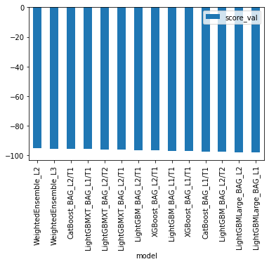

```python
predictor_new_hpo.leaderboard(silent=True).plot(kind="bar", x="model", y="score_val")
```

```python
predictions_new_hpo = predictor_new_hpo.predict(test)
```

```python
# Checking if there are any negative values
predictions_new_hpo.describe()
```

```
count    6493.000000
mean      187.507507
std       151.316772
min       -36.784767
25%        51.692039
50%       162.946442
75%       282.755493
max       726.046204
Name: count, dtype: float64
```

```python
# Setting all negative values to zero
predictions_new_hpo[predictions_new_hpo < 0] = 0
predictions_new_hpo.describe()
```

```
count    6493.000000
mean      187.627060
std       151.163315
min         0.000000
25%        51.692039
50%       162.946442
75%       282.755493
max       726.046204
Name: count, dtype: float64
```

```python
# Same submitting predictions
submission_new_hpo = submission
submission_new_hpo["count"] = predictions_new_hpo
submission_new_hpo.to_csv("submission_new_hpo.csv", index=False)
```

```python
!kaggle competitions submit -c bike-sharing-demand -f submission_new_hpo.csv -m "new features with hyperparameters"
```

```
Successfully submitted to Bike Sharing Demand
```

```python
!kaggle competitions submissions -c bike-sharing-demand | tail -n +1 | head -n 6
```

```
fileName                     date                 description                        status    publicScore  privateScore
---------------------------  -------------------  ---------------------------------  --------  -----------  ------------
submission_new_hpo.csv       2023-02-03 10:54:55  new features with hyperparameters  complete  0.77392      0.77392
submission_new_hpo.csv       2023-02-02 11:59:53  new features with hyperparameters  complete  0.67866      0.67866
submission_new_features.csv  2023-02-02 11:42:46  new features                       complete  0.67867      0.67867
submission_initial.csv       2023-02-02 11:26:30  first raw submission               complete  1.32970      1.32970
```